```
author: "Raphael Edison Most"
date: "5 4 2021"
output:
  html_document:
    toc: true
    theme: lumen
    toc_depth: 5
includes:
  in_header: ../2_Assets/header.Rhtml
```

Wird leider nicht richtig umgesetzt

[output not shown]

```r
# FEHLERMELDUNG konnte Funktion "theme_set" nicht finden wenn es ins r setup eingefügt wurde

# theme_set(theme_minimal())
# theme_update(panel.background = element_rect(fill = "transparent", colour = NA),
#              plot.background = element_rect(fill = "transparent", colour = NA))
#
# ggplot <- function(...) ggplot2::ggplot(...) +
#   scale_fill_gradientn(colors = c('#555555','#6BB7B9')) +
#   scale_colour_gradientn(colors = c('#555555','#6BB7B9'))
```

### Präambel

Dieser Bericht analysiert Veränderungen in den Neueinstellungen und den Preisen von Airbnb Objekten in Berlin, Deutschland. Er wurde zum Zwecke der Übung auf Basis öffentlich verfügbarer Daten [^1] erstellt und repräsentiert einzig die Position der Autoren. Es besteht keine Beziehung zu Airbnb.

### Neueinstellungen

#### Entwicklung

Seit 02.01.2018 wurden in Berlin 5007 Airbnb Wohnungen eingestellt. Von diesen Wohnungn weisen aktuell 73% Verfügbarkeiten von durchschnittlich 47.5 Tagen für die nächsten 3 Monate auf.

Einstellungen von Airbnb Wohnungen haben im letzten Jahr stark zugenommen. Im Jahr 2019 wurden insgesamt 3274 neue Wohnungen eingestellt, wohingegend im Jahr 2018 nur 1733 Wohnungen eingestellt wurden. Dies entspricht einem Zuwachs von 89%.

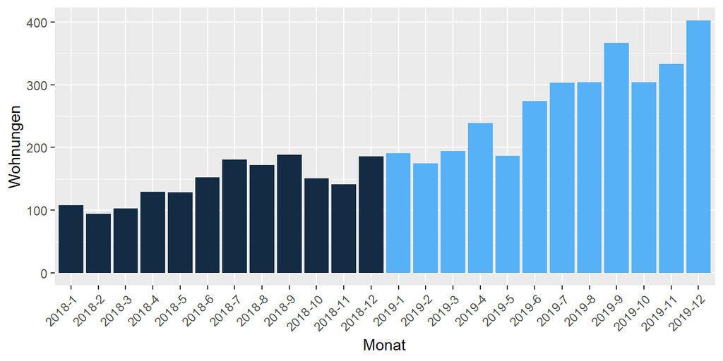

Abbildung 1. Neueinstellungen pro Monat.

#### Stadtteile

```r
# Berechne Häufigkeiten über die Bezirke
stadtteile <- Airbnb_1819 %>%
              group_by(Stadtteil,
                       Jahr = year(Erstellungsdatum)) %>%
              summarize(Wohnungen = n()) %>%
              ungroup() %>%
              arrange(desc(Jahr), Wohnungen) %>%
              mutate(Stadtteil = as_factor(Stadtteil))

# here this did not work
cap = "Abbildung 2. Neueinstellungen pro Bezirk."
```

Neueinstellungen fallen nach wie vor sehr unterschiedlich in den Bezirken aus. Die meisten Neueinstellungen im Jahr 2019 gab es in Friedrichshain-Kreuzberg, die wenigsten in Marzahn - Hellersdorf.

Die grössten Veränderungen gab es in Marzahn - Hellersdorf und Treptow - Köpenick. In Marzahn - Hellersdorf, wuchsen die Neueinstellungen um -13.3%, in Treptow - Köpenick wuchsen die Neueinstellungen um 137.8%.

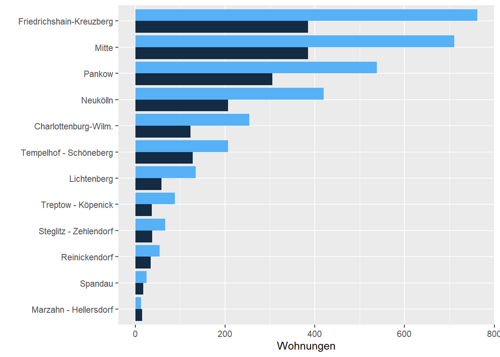

### Preis

This here gives an error, included as a comment that i can show it, without blocking the rest from running

```r
# Der durchschnittliche Preis der Neueinstellungen beträgt `r round(mean(airbnb_1819 %>% pull(Preis)),1)`E. Im Vergleich zum Vorjahr sind die Preise der Neueinstellungen um `r m <- mean(airbnb_1819 %>% filter(year(Erstellungsdatum) == 2019) %>% pull(Preis))/ mean(airbnb_1819 %>% filter(year(Erstellungsdatum) == 2018) %>% pull(Preis)) ; round(m, 3) * 100 - 100`% gestiegen.
```

#### Einfluss Ausstattung

```
Jetzt zu etwas sehr bizarrem.
Zum gefühlt dritten Mal musste ich den ganzen Text neu schreiben, da der Cursor ein Zeichen weiter war als der Buchstabe an sich, beim ersten Mal als dies aufgetreten ist habe ich r und den ganzen Computer neu gestartet, da es jetzt zum dritten Mal passiert ist, glaube ich es liegt am copy paste von…
Wenn ich 72.9 löschen möchte, und den Cursor hinter 9 platziere löscht es «.» Anstelle von «9». Das Einfügen von code geschieht auch nicht am richtigen Ort. Dies tritt bei beiden der folgenden Textabschnitte auf, bei den bisherigen Orten habe ich es mir nicht notiert.
```

##### L - Preis: Tabelle 1 erzeugen

Erstelle einen neuen Code Chunk mit einer Tabelle basierend auf ausstattung. Verwende dafür die kable() Funktion. Siehe unten.

```r
# FEHLERMELDUNG ausstattung KONNTE NICHT GEFUNDEN WERDEN

# # Plotte Tabelle mit Austattungsmerkmalen
# ausstattung %>% kable(format = 'html')
```

#### Regressionsmodell

```r
# FEHLERMELDUNG airbnd_1819 KONNTE NICHT GEFUNDEN WERDEN

# # Reduzierter Vektor mit Ausstattungsmerkmalen
# ausstattung_var <- c('Küche','TV','Terrasse_Balkon','Check_in_24h')
#
# # Bereit den Datensatz für die Regression vor
# ausstattung <-
#   airbnb_1819 %>%
#     mutate(Hotel = Unterkunftsart %in% c('Boutique hotel', 'Hotel')) %>%
#     select(Preis, Hotel, all_of(ausstattung_var))
#
# # Rechne Regression des Preises auf Austattungsmerkmale und Hotel
# ausstattung_mod <-
#   ausstattung %>%
#     lm(formula = Preis ~ .)
#
# # Bestimme Anteil Hotels in 2018 und 2019
# hotel <-
#   airbnb_1819 %>%
#     group_by(year(Erstellungsdatum)) %>%
#     summarize(Anteil = mean(Unterkunftsart %in% c('Boutique hotel', 'Hotel')))
```

```r
# AUFGRUND DER VORHERIGEN FEHLER KONNTE DIES HIER NICHT AUSGEFÜHT WERDEN

# # Tabelle mit Ergebnissen der Regression
# tab_model(ausstattung_mod)
#
# pred.labels = c('Achsenabschnitt', names(ausstattung)[-1])
# title = 'Table 2. Regression des Preises auf die Ausstattung.'
```

DISCLAIMER: Aufgrund der vielen bisherigen Fehlern habe ich hier abgebrochen und die Aufgaben P und Q nicht begonnen.

[^1]: Daten wurde heruntergeladen von [insideairbnb.com](http://insideairbnb.com/get-the-data.html)